# NBA Playoff Performance Prediction (3)

One limitation of neural networks in this context is the lack of interpretability. Unlike tree-based models, the NN does not provide feature importances, making it more difficult to understand which predictors had the greatest influence. However, the NN serves as a valuable nonlinear benchmark, offering a flexible function approximation method that complements the results of the other models in our analysis.

[output not shown]

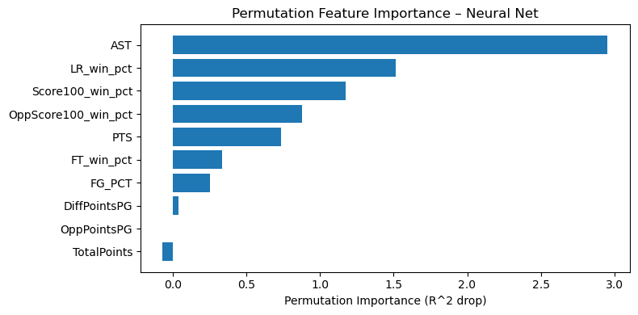

```python
from scikeras.wrappers import KerasRegressor
from sklearn.inspection import permutation_importance
from sklearn.model_selection import train_test_split
import numpy as np
import matplotlib.pyplot as plt
import pandas as pd
from tensorflow.keras.models import Sequential
from tensorflow.keras.layers import Dense

# Scaler
X_scaled = scaler.transform(X)

# Define model
def build_model():
    model = Sequential([
        Dense(32, activation='relu', input_shape=(X_scaled.shape[1],)),
        Dense(16, activation='relu'),
        Dense(1)
    ])
    model.compile(optimizer='adam', loss='mse')
    return model

# Fit model
model = build_model()
model.fit(X_train, y_train, epochs=100, batch_size=8, verbose=0)

# Manual permutation
from sklearn.metrics import r2_score

# Baseline performance
y_pred_baseline = model.predict(X_test).flatten()
baseline_r2 = r2_score(y_test, y_pred_baseline)

import copy
import random

importances = []

for col_idx in range(X_test.shape[1]):
    X_permuted = copy.deepcopy(X_test)
    np.random.shuffle(X_permuted[:, col_idx])

    y_pred_permuted = model.predict(X_permuted).flatten()
    permuted_r2 = r2_score(y_test, y_pred_permuted)

    importances.append(baseline_r2 - permuted_r2)


perm_importances = pd.DataFrame({
    'Feature': features,
    'Importance': importances
}).sort_values(by='Importance', ascending=False)

plt.figure(figsize=(8, 4))
plt.barh(perm_importances['Feature'], perm_importances['Importance'])
plt.xlabel('Permutation Importance (R^2 drop)')
plt.title('Permutation Feature Importance – Neural Net')
plt.gca().invert_yaxis()
plt.tight_layout()
plt.show()
```

[output not shown]

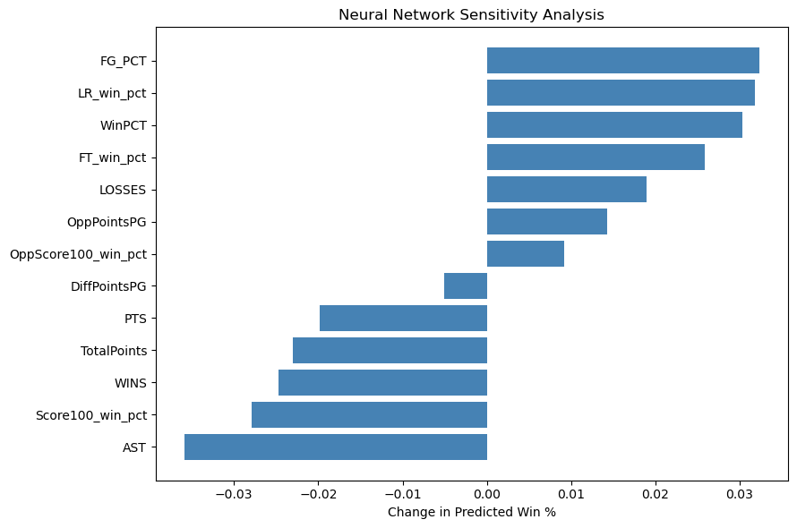

```python
import numpy as np
import pandas as pd
import matplotlib.pyplot as plt
from sklearn.model_selection import train_test_split
from sklearn.preprocessing import StandardScaler
from tensorflow.keras.models import Sequential
from tensorflow.keras.layers import Dense


features = [
    'PTS', 'AST', 'FG_PCT', 'DiffPointsPG',
    'FT_win_pct', 'LR_win_pct',
    'TotalPoints', 'OppPointsPG',
    'Score100_win_pct', 'OppScore100_win_pct',
    'WINS', 'LOSSES', 'WinPCT'
]



X = df_merged[features].values
y = df_merged['WinPCT'].values

scaler = StandardScaler()
X_scaled = scaler.fit_transform(X)


X_train, X_test, y_train, y_test = train_test_split(X_scaled, y, test_size=0.2, random_state=134)


model = Sequential([
    Dense(32, activation='relu', input_shape=(X_train.shape[1],)),
    Dense(16, activation='relu'),
    Dense(1)
])
model.compile(optimizer='adam', loss='mse')
model.fit(X_train, y_train, epochs=100, batch_size=8, verbose=0)


sample = X_test[0].reshape(1, -1)
sensitivity_results = []

for i, col in enumerate(features):
    perturbed = sample.copy()
    perturbed[0, i] += 0.1
    change = model.predict(perturbed)[0][0] - model.predict(sample)[0][0]
    sensitivity_results.append((col, round(change, 5)))


sensitivity_df = pd.DataFrame(sensitivity_results, columns=['Feature', 'DeltaPrediction']).sort_values(by='DeltaPrediction', ascending=False)

plt.figure(figsize=(9, 6))
plt.barh(sensitivity_df['Feature'], sensitivity_df['DeltaPrediction'], color='steelblue')
plt.xlabel('Change in Predicted Win %')
plt.title('Neural Network Sensitivity Analysis')
plt.gca().invert_yaxis()
plt.tight_layout()
plt.show()
```

To evaluate which features most influenced our neural network’s prediction of playoff win percentage, we conducted a one-variable sensitivity analysis. Each feature was nudged slightly while keeping all others constant, and the change in predicted win percentage was recorded.

Interestingly, AST, DiffPointsPG, and WINS had small or even negative effects in this sample, which could reflect multicollinearity or how those stats behave in combination with others. While surprising at first glance, this highlights one of the strengths of neural networks: capturing non-obvious interactions.

Overall, the sensitivity chart supports key basketball insights — shooting efficiency, rebounding, and opponent containment play strong roles in playoff success — while also reflecting the model’s flexibility in weighing features adaptively.

## Here are the actual NBA Playoff results grouped by series:

```python
from nba_api.stats.endpoints import TeamGameLogs
import pandas as pd

season = '2024-25'
logs = TeamGameLogs(season_nullable=season, season_type_nullable='Playoffs').get_data_frames()[0]
logs['WIN'] = logs['WL'] == 'W'

# Normalize series names
def normalize_series(m):
    teams = m.replace('@', '').replace('vs.', '').split()
    return " vs ".join(sorted(set(teams)))

logs['SERIES_ID'] = logs['MATCHUP'].apply(normalize_series)


# Full name to abbreviation mapping
team_name_to_abbr = {
    'Boston Celtics': 'BOS',
    'New York Knicks': 'NYK',
    'Orlando Magic': 'ORL',
    'Indiana Pacers': 'IND',
    'Cleveland Cavaliers': 'CLE',
    'Miami Heat': 'MIA',
    'Denver Nuggets': 'DEN',
    'LA Clippers': 'LAC',
    'Oklahoma City Thunder': 'OKC',
    'Detroit Pistons': 'DET',
    'Golden State Warriors': 'GSW',
    'Houston Rockets': 'HOU',
    'Minnesota Timberwolves': 'MIN',
    'Milwaukee Bucks': 'MIL',
    'Los Angeles Lakers': 'LAL',
    'Memphis Grizzlies': 'MEM'
}

def get_2025_series_results_detailed_abbr():
    # Count wins for each team in each series
    win_counts = logs.groupby(['SERIES_ID', 'TEAM_NAME'])['WIN'].sum().reset_index()

    # Aggregate into a structured list of series with team abbreviations
    series_data = []
    for series_id, group in win_counts.groupby('SERIES_ID'):
        teams = group.sort_values('WIN', ascending=False).reset_index(drop=True)
        if len(teams) == 2:
            team1_full = teams.loc[0, 'TEAM_NAME']
            wins1 = teams.loc[0, 'WIN']
            team2_full = teams.loc[1, 'TEAM_NAME']
            wins2 = teams.loc[1, 'WIN']

            # Convert to abbreviations
            team1 = team_name_to_abbr.get(team1_full, team1_full)
            team2 = team_name_to_abbr.get(team2_full, team2_full)
            winner = team1 if wins1 > wins2 else team2

            series_data.append({
                'SERIES': f"{team1} vs {team2}",
                'Winner': team1,
                'WINS_1': wins1,
                'Loser': team2,
                'WINS_2': wins2,
                'WINNER': winner
            })

    return pd.DataFrame(series_data)

# Usage
series_summary = get_2025_series_results_detailed_abbr()
print(series_summary)
```

```
        SERIES Winner  WINS_1 Loser  WINS_2 WINNER
0   NYK vs BOS    NYK       4   BOS       2    NYK
1   BOS vs ORL    BOS       4   ORL       1    BOS
2   IND vs CLE    IND       4   CLE       1    IND
3   CLE vs MIA    CLE       4   MIA       0    CLE
4   DEN vs LAC    DEN       4   LAC       3    DEN
5   OKC vs DEN    OKC       4   DEN       3    OKC
6   NYK vs DET    NYK       4   DET       2    NYK
7   GSW vs HOU    GSW       4   HOU       3    GSW
8   MIN vs GSW    MIN       4   GSW       1    MIN
9   IND vs MIL    IND       4   MIL       1    IND
10  IND vs NYK    IND       4   NYK       2    IND
11  IND vs OKC    IND       1   OKC       1    OKC
12  MIN vs LAL    MIN       4   LAL       1    MIN
13  OKC vs MEM    OKC       4   MEM       0    OKC
14  OKC vs MIN    OKC       4   MIN       1    OKC
```

#### The actual results are being compared to the results predicted by the model.

```python
import random
import pandas as pd

def simulate_series_from_probs(matchups, team_probs_df, max_games=7):
    team_prob_dict = dict(zip(team_probs_df['TEAM_NAME'], team_probs_df['WIN_PROB']))

    results = []
    for team1, team2 in matchups:
        prob1 = team_prob_dict.get(team1, 0.5)
        prob2 = team_prob_dict.get(team2, 0.5)

        team1_wins = 0
        team2_wins = 0
        for game in range(max_games):
            # Normalize win probabilities
            p_total = prob1 + prob2
            p1 = prob1 / p_total
            winner = random.choices([team1, team2], weights=[p1, 1 - p1])[0]

            if winner == team1:
                team1_wins += 1
            else:
                team2_wins += 1

            if team1_wins == 4 or team2_wins == 4:
                break

        results.append({
            'SERIES': f"{team1} vs {team2}",
            'TEAM_1': team1,
            'TEAM_2': team2,
            'TEAM_1_WINS': team1_wins,
            'TEAM_2_WINS': team2_wins,
            'PREDICTED_WINNER': team1 if team1_wins > team2_wins else team2
        })

    return pd.DataFrame(results)
```

```python
features = [
    'PTS', 'AST', 'FG_PCT', 'DiffPointsPG',
    'FT_win_pct', 'LR_win_pct',
    'OppPointsPG', 'TotalPoints',
    'Score100_win_pct', 'OppScore100_win_pct'
]

# Create a copy of team stats
df = df_team_metrics.copy()

# Engineer necessary columns
df['DiffPointsPG'] = df['PTS'] - df.get('OPP_PTS', 0)
df['FT_win_pct'] = df.get('FT_PCT', 0)
df['LR_win_pct'] = df.get('W_PCT', 0)
df['OppPointsPG'] = df.get('OPP_PTS', 0)
df['TotalPoints'] = df['PTS']
df['Score100_win_pct'] = 0.5
df['OppScore100_win_pct'] = 0.5

# Prepare input for prediction
X = df[features]
team_abbrevs = df['TEAM_ABBREVIATION']

# Predict WinPCT using trained model
win_probs = rf.predict(X)

# Create team probability DataFrame
team_probs_df = pd.DataFrame({
    'TEAM_NAME': team_abbrevs,
    'WIN_PROB': win_probs
})
```

```python
from collections import Counter

def extract_playoff_matchups_abbr(series_summary_df):
    matchups = []
    for _, row in series_summary_df.iterrows():
        winner_abbr = team_name_to_abbr.get(row['Winner'], row['Winner'])
        loser_abbr = team_name_to_abbr.get(row['Loser'], row['Loser'])
        matchups.append((winner_abbr, loser_abbr))
    return matchups

simulated_results = simulate_series_from_probs(extract_playoff_matchups_abbr(series_summary), team_probs_df)
print("Simulated Series Results:")
print(simulated_results)
```

```
Simulated Series Results:
        SERIES TEAM_1 TEAM_2  TEAM_1_WINS  TEAM_2_WINS PREDICTED_WINNER
0   NYK vs BOS    NYK    BOS            4            3              NYK
1   BOS vs ORL    BOS    ORL            4            1              BOS
2   IND vs CLE    IND    CLE            4            1              IND
3   CLE vs MIA    CLE    MIA            1            4              MIA
4   DEN vs LAC    DEN    LAC            1            4              LAC
5   OKC vs DEN    OKC    DEN            3            4              DEN
6   NYK vs DET    NYK    DET            3            4              DET
7   GSW vs HOU    GSW    HOU            4            2              GSW
8   MIN vs GSW    MIN    GSW            4            1              MIN
9   IND vs MIL    IND    MIL            4            1              IND
10  IND vs NYK    IND    NYK            4            2              IND
11  IND vs OKC    IND    OKC            4            1              IND
12  MIN vs LAL    MIN    LAL            1            4              LAL
13  OKC vs MEM    OKC    MEM            2            4              MEM
14  OKC vs MIN    OKC    MIN            4            1              OKC
```

This simulation is then run 10000 times and the most common results are chosen

```python
all_winners = []

for _ in range(10000):
    matchups = extract_playoff_matchups_abbr(series_summary)
    simulation_df = simulate_series_from_probs(matchups, team_probs_df)
    winner_tuple = tuple(simulation_df['PREDICTED_WINNER'].tolist())
    all_winners.append(winner_tuple)

# Count most common outcome
from collections import Counter
counter = Counter(all_winners)
most_common_result, freq = counter.most_common(1)[0]

# Convert to DataFrame for inspection
most_common_df = pd.DataFrame({'PREDICTED_WINNER': most_common_result})
print(most_common_df)

def print_series_winners(series_summary):
    print("Series Winners:")
    for _, row in series_summary.iterrows():
        print(f"{_} : {row['WINNER']}")

print_series_winners(series_summary)
```

```
   PREDICTED_WINNER
0               BOS
1               BOS
2               IND
3               CLE
4               LAC
5               OKC
6               NYK
7               GSW
8               GSW
9               IND
10              NYK
11              IND
12              LAL
13              MEM
```

[output cut: 17 more lines]

```python
# Here the predictions and actual results are directly compared and the incorrect predictions are printed
def compare_predictions(most_common_df, series_summary):
    predicted_winners = most_common_df['PREDICTED_WINNER'].tolist()
    actual_winners = series_summary['WINNER'].tolist()

    correct = 0
    total = len(actual_winners)
    mismatches = []

    for i in range(total):
        predicted = predicted_winners[i] if i < len(predicted_winners) else 'N/A'
        actual = actual_winners[i]
        if predicted == actual:
            correct += 1
        else:
            mismatches.append({
                'Index': i,
                'Series': series_summary.iloc[i]['SERIES'],
                'Predicted': predicted,
                'Actual': actual
            })

    print(f"\n Correct Predictions: {correct}/{total} ({(correct / total) * 100:.1f}%)")

    if mismatches:
        print("Mismatches:")
        for m in mismatches:
            print(f"{m['Index']}: {m['Series']} -> Predicted: {m['Predicted']}, Actual: {m['Actual']}")
compare_predictions(most_common_df, series_summary)
```

```
 Correct Predictions: 8/15 (53.3%)
Mismatches:
0: NYK vs BOS -> Predicted: BOS, Actual: NYK
4: DEN vs LAC -> Predicted: LAC, Actual: DEN
8: MIN vs GSW -> Predicted: GSW, Actual: MIN
10: IND vs NYK -> Predicted: NYK, Actual: IND
11: IND vs OKC -> Predicted: IND, Actual: OKC
12: MIN vs LAL -> Predicted: LAL, Actual: MIN
13: OKC vs MEM -> Predicted: MEM, Actual: OKC
```